# assignment 1

prabakaran. C

2023-07-18

```r
library(ISLR)
auto=data.frame(Auto)
auto
```

```
##      mpg cylinders displacement horsepower weight acceleration year origin
## 1   18.0         8        307.0        130   3504         12.0   70      1
## 2   15.0         8        350.0        165   3693         11.5   70      1
## 3   18.0         8        318.0        150   3436         11.0   70      1
## 4   16.0         8        304.0        150   3433         12.0   70      1
## 5   17.0         8        302.0        140   3449         10.5   70      1
## 6   15.0         8        429.0        198   4341         10.0   70      1
## 7   14.0         8        454.0        220   4354          9.0   70      1
## 8   14.0         8        440.0        215   4312          8.5   70      1
## 9   14.0         8        455.0        225   4425         10.0   70      1
## 10  15.0         8        390.0        190   3850          8.5   70      1
## 11  15.0         8        383.0        170   3563         10.0   70      1
## 12  14.0         8        340.0        160   3609          8.0   70      1
## 13  15.0         8        400.0        150   3761          9.5   70      1
## 14  14.0         8        455.0        225   3086         10.0   70      1
```

[output cut: 771 more lines]

1. Which of the predictors are quantitative, and which are qualitative?

```r
str(auto)
```

```
## 'data.frame':    392 obs. of  9 variables:
##  $ mpg         : num  18 15 18 16 17 15 14 14 14 15 ...
##  $ cylinders   : num  8 8 8 8 8 8 8 8 8 8 ...
##  $ displacement: num  307 350 318 304 302 429 454 440 455 390 ...
##  $ horsepower  : num  130 165 150 150 140 198 220 215 225 190 ...
##  $ weight      : num  3504 3693 3436 3433 3449 ...
##  $ acceleration: num  12 11.5 11 12 10.5 10 9 8.5 10 8.5 ...
##  $ year        : num  70 70 70 70 70 70 70 70 70 70 ...
##  $ origin      : num  1 1 1 1 1 1 1 1 1 1 ...
##  $ name        : Factor w/ 304 levels "amc ambassador brougham",..: 49 36 231 14 161 141 54 223 241 2 ...
```

Answer:mpg, displacement, horsepower, weight, accelaration, year-Quantitative; cylinders, origin, name-Qualitative.

2. What is the range of each quantitative predictor? You can answer this using the range() function.

```r
for(i in c(1,3,4,5,6,7)){
 print( range(auto[,i]))
}
```

```
## [1]  9.0 46.6
## [1]  68 455
## [1]  46 230
## [1] 1613 5140
## [1]  8.0 24.8
## [1] 70 82
```

3. What is the mean and standard deviation of each quantitative predictor?

```r
for(i in c(1,3,4,5,6,7)){
 print( mean(auto[,i]))
}
```

```
## [1] 23.44592
## [1] 194.412
## [1] 104.4694
## [1] 2977.584
## [1] 15.54133
## [1] 75.97959
```

```r
for(i in c(1,3,4,5,6,7)){
 print( sd(auto[,i]))
}
```

```
## [1] 7.805007
## [1] 104.644
## [1] 38.49116
## [1] 849.4026
## [1] 2.758864
## [1] 3.683737
```

4. Now remove the 10th through 85th observations. What is the range, mean, and standard deviation of each predictor in the subset of the data that remains?

```r
auto=Auto[-(10:85),]
auto
```

```
##      mpg cylinders displacement horsepower weight acceleration year origin
## 1   18.0         8          307        130   3504         12.0   70      1
## 2   15.0         8          350        165   3693         11.5   70      1
## 3   18.0         8          318        150   3436         11.0   70      1
## 4   16.0         8          304        150   3433         12.0   70      1
## 5   17.0         8          302        140   3449         10.5   70      1
## 6   15.0         8          429        198   4341         10.0   70      1
## 7   14.0         8          454        220   4354          9.0   70      1
## 8   14.0         8          440        215   4312          8.5   70      1
## 9   14.0         8          455        225   4425         10.0   70      1
## 87  14.0         8          304        150   3672         11.5   73      1
## 88  13.0         8          350        145   3988         13.0   73      1
## 89  14.0         8          302        137   4042         14.5   73      1
## 90  15.0         8          318        150   3777         12.5   73      1
## 91  12.0         8          429        198   4952         11.5   73      1
```

[output cut: 619 more lines]

```r
for(i in c(1,3,4,5,6,7)){
 print( range(auto[,i]))
}
```

```
## [1] 11.0 46.6
## [1]  68 455
## [1]  46 230
## [1] 1649 4997
## [1]  8.5 24.8
## [1] 70 82
```

```r
for(i in c(1,3,4,5,6,7)){
 print( mean(auto[,i]))
}
```

```
## [1] 24.40443
## [1] 187.2405
## [1] 100.7215
## [1] 2935.972
## [1] 15.7269
## [1] 77.14557
```

```r
for(i in c(1,3,4,5,6,7)){
 print( sd(auto[,i]))
}
```

```
## [1] 7.867283
## [1] 99.67837
## [1] 35.70885
## [1] 811.3002
## [1] 2.693721
## [1] 3.106217
```

5. Using the full data set, investigate the predictors graphically, using scatterplots or other tools of your choice. Create some plots highlighting the relationships among the predictors. Comment on your findings.

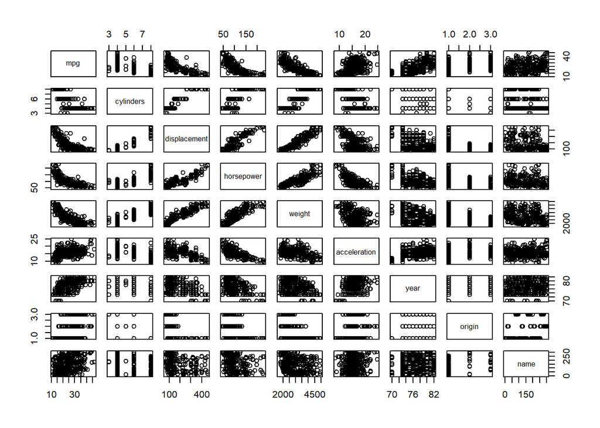

```r
pairs(auto)
```

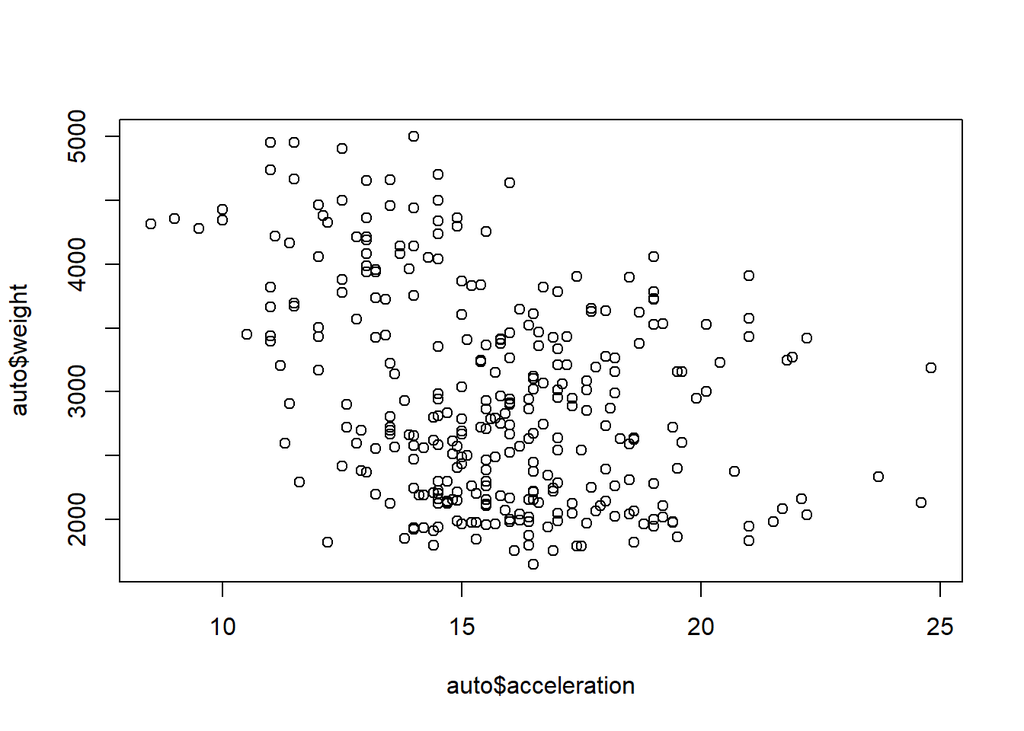

```r
plot(auto$acceleration,auto$weight)
```

There is a negative correlation that shows when weight increases accelaration decreases.

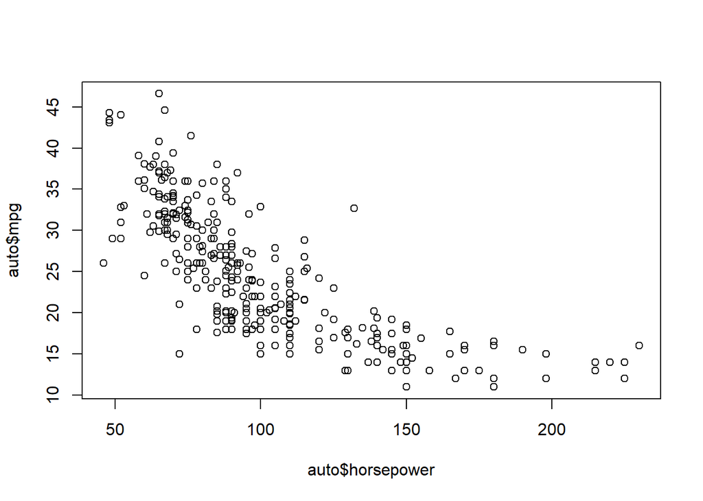

```r
plot(auto$horsepower, auto$mpg)
```

There is a negative correlation that is when horsepower increases, mpg decreases.

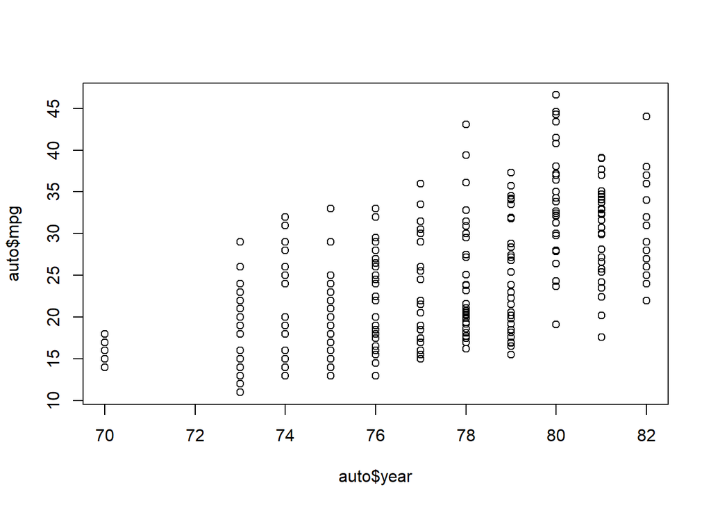

```r
plot(auto$year, auto$mpg)
```

There is a positive correlation that shows that as year increases, mpg also increases.

6. Suppose that we wish to predict gas mileage (mpg) on the basis of the other variables. Do your plots suggest that any of the other variables might be useful in predicting mpg? Justify your answer

Answer: Yes, from these graphs we can see some variables have positive, and some have negative, relationships to mpg outcome. mpg and horsepower have a negative relationship to one another (when horsepower increases, mpg decreases) while year and mpg have a positive relationship with each other (as year increases mpg also increases).